# Week 4 Recitation

Chris

9/25/2019

[figure not shown]

# Empirical Distributions

Lets load a data set. This is the expression of three genes from a group of cells in a single-cell experiment.

```r
example.expression.data <- read.delim("Week_4_Example.tsv")
```

Lets do some basic analysis of this data

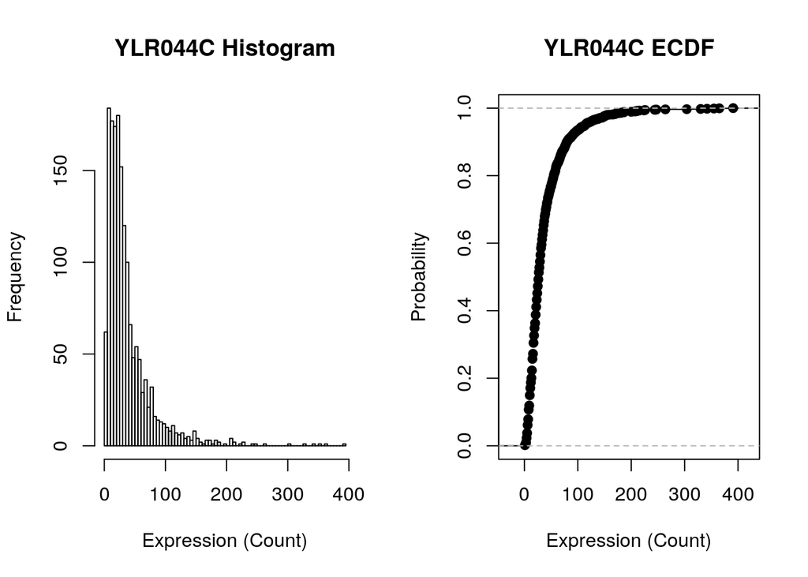

```r
# The ecdf() function calculates an EMPIRICAL CDF
# It returns an ECDF object
# All you need to know about that object is that plot() knows what it is and will handle it fine
ylr044c.data <- example.expression.data$YLR044C
ylr044c.ecdf <- ecdf(ylr044c.data)

# Lets plot the histogram against the ECDF
par(mfrow=c(1,2))
hist(ylr044c.data, main="YLR044C Histogram", breaks = 100, xlab="Expression (Count)")
plot(ylr044c.ecdf, main = "YLR044C ECDF", xlab="Expression (Count)", ylab="Probability")
```

Yep, that’s data. Let’s see if it’s normally distributed-

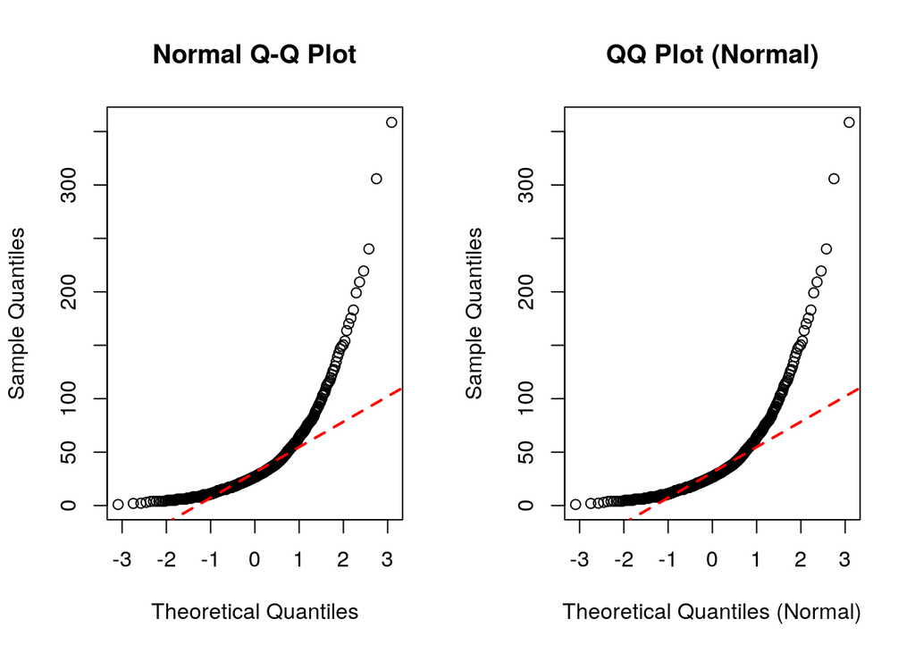

```r
par(mfrow=c(1,2))

quantile.data <- quantile(ylr044c.data, ppoints(500))
normal.quantiles <- qnorm(ppoints(500))

## The qqnorm function is a quick way to do a qqplot for the normal distribution
qqnorm(quantile.data)
qqline(quantile.data, col = 2, lwd = 2, lty = 2)

## The qqplot function is a general plot function - you can plot a QQ plot for any distribution
## Here we're just doing normal again
qqplot(normal.quantiles,quantile.data, main = "QQ Plot (Normal)", xlab="Theoretical Quantiles (Normal)", ylab="Sample Quantiles")
qqline(quantile.data, col = 2, lwd = 2, lty = 2)
```

Yep, those are plots. What do they mean?

Actually I don’t care. I will model this data with a normal distribution - but how?

```r
norm.fit <- MASS::fitdistr(ylr044c.data, densfun = "normal")
norm.fit
```

```
##       mean          sd
##   38.8619221   40.1771750
##  ( 0.9908969) ( 0.7006699)
```

Those certainly look like numbers. This explicitly forces the model to be normal - lets see how this looks when we compare the ECDF to the fit CDF.

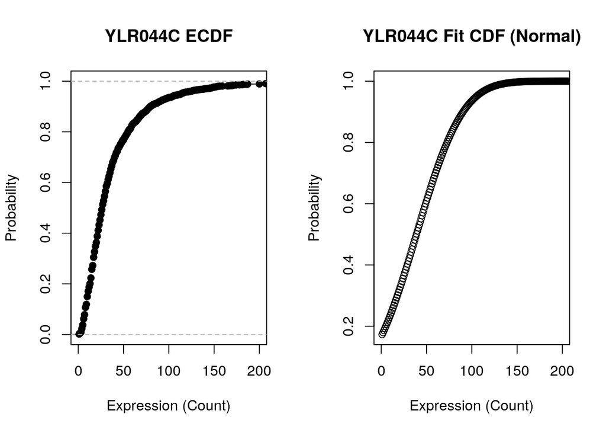

```r
par(mfrow=c(1,2))

fit.normal.cdf <- pnorm(1:400, mean = norm.fit$estimate['mean'], sd = norm.fit$estimate['sd'])

plot(ylr044c.ecdf, main = "YLR044C ECDF", xlab="Expression (Count)", ylab="Probability", xlim=c(0,200))
plot(fit.normal.cdf, main = "YLR044C Fit CDF (Normal)", xlab="Expression (Count)", ylab="Probability", xlim=c(0,200))
```

That’s not all that close. Do the QQ plots look any better?

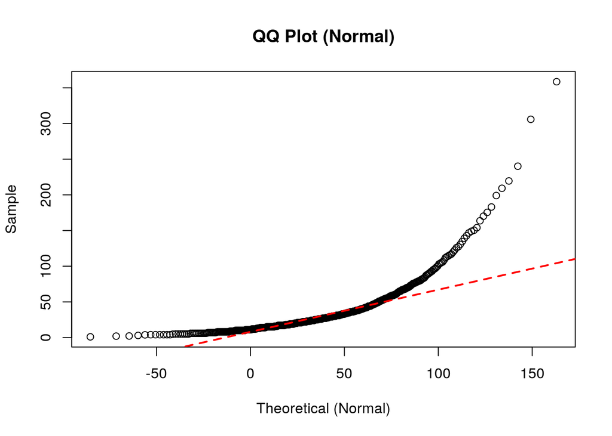

```r
normal.fit.quantile.function <- function(x) {qnorm(x, mean=norm.fit$estimate['mean'], sd = norm.fit$estimate['sd'])}
normal.fit.quantiles <- normal.fit.quantile.function(ppoints(500))

qqplot(normal.fit.quantiles, quantile.data, main = "QQ Plot (Normal)", xlab="Theoretical (Normal)", ylab="Sample")
qqline(quantile.data, distribution = normal.fit.quantile.function,  col = 2, lwd = 2, lty = 2)
```

We could use other distributions I suppose.

```r
geom.fit <- MASS::fitdistr(example.expression.data$YLR044C, densfun = "geometric")
geom.fit
```

```
##        prob
##   0.0250865976
##  (0.0006109053)
```

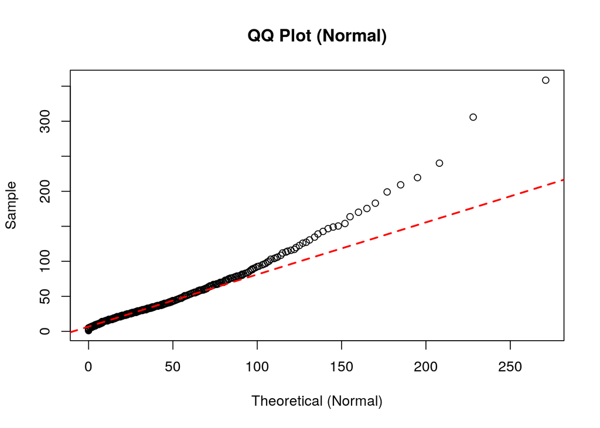

```r
geom.fit.quantile.function <- function(x) {qgeom(x, prob = geom.fit$estimate['prob'])}
geom.fit.quantiles <- geom.fit.quantile.function(ppoints(500))

qqplot(geom.fit.quantiles, quantile.data, main = "QQ Plot (Normal)", xlab="Theoretical (Normal)", ylab="Sample")
qqline(quantile.data, distribution = geom.fit.quantile.function,  col = 2, lwd = 2, lty = 2)
```

That’s better at least - but does another distribution fit best?

Break into 3 groups and use the data provided to:

1. Load and look breifly at the structure of your data
2. Plot histograms for each of the 3 genes
3. Use `qqplots` and `MASS::fitdistr` to check and see which distributions fit the data well. `fitdistr` will take the following `densfun` arguments:
- “normal”
- “geometric”
- “negative binomial”
- “Poisson”